# Homework Two

DACSS 603

Cynthia Hester  
March 5,2022

## Question 1

United Nations (Data file: UN11) The data in the file UN11 contains several variables, including ppgdp, the gross national product per person in U.S. dollars, and fertility, the birth rate per 1000 females, both from the year 2009. The data are for 199 localities, mostly UN member countries, but also other areas such as Hong Kong that are not independent countries. The data were collected from the United Nations (2011). We will study the dependence of fertility on ppgdp.

1.1.1. Identify the predictor and the response.

1.1.2 Draw the scatterplot of fertility on the vertical axis versus ppgdp on the horizontal axis and summarize the information in this graph. Does a straight-line mean function seem to be plausible for a summary of this graph?

1.1.3 Draw the scatterplot of log(fertility) versus log(ppgdp) using natural logarithms. Does the simple linear regression model seem plausible for a summary of this graph? If you use a different base of logarithms, the shape of the graph won’t change, but the values on the axes will change.

### Solution

**1.1.1. Identify the predictor and the response.**

The predictor is *ppgdp*. This is because the problem is studying the dependence of fertility on *ppgdp* (gross national product per person) which is independent/explanatory.

The response variable is *fertility*. This is because *fertility* is the dependent variable in relation to *ppgdp*.

**1.1.2 Draw the scatterplot of fertility on the vertical axis versus ppgdp on the horizontal axis and summarize the information in this graph. Does a straight-line mean function seem to be plausible for a summary of this graph?**

#### First, we import the data from the United Nations (Datafile:UN11) contained in data accompanying the ALR text book data set.

```r
data("UN11")                      #load UN11 data, which contains
United_Nations_11<-UN11           #"UN11" renamed for easier readability
head(United_Nations_11)
```

```
                region  group fertility   ppgdp lifeExpF pctUrban
Afghanistan       Asia  other     5.968   499.0    49.49       23
Albania         Europe  other     1.525  3677.2    80.40       53
Algeria         Africa africa     2.142  4473.0    75.00       67
Angola          Africa africa     5.135  4321.9    53.17       59
Anguilla     Caribbean  other     2.000 13750.1    81.10      100
Argentina   Latin Amer  other     2.172  9162.1    79.89       93
```

#### I now separate the two variables, *fertility* and *ppgdp* from the UN11 dataset for inspection

```r
#separates fertility and ppgdp from dataset

United_Nations_11 <- United_Nations_11 %>%
  select(c(fertility,ppgdp))
head(United_Nations_11,5)               # First five rows of variables fertility and ppgdp verified
```

```
            fertility   ppgdp
Afghanistan     5.968   499.0
Albania         1.525  3677.2
Algeria         2.142  4473.0
Angola          5.135  4321.9
Anguilla        2.000 13750.1
```

Here I use a table to represent the variables extracted from the UN11 data

```r
kable(head(United_Nations_11),format = "markdown",digits = 3,colnames = c('fertility','ppgdp'),
      caption = "United Nations Fertility and Gross National Product Per Person in USD")
```

Table 1: United Nations Fertility and Gross National Product Per Person in USD

|  | fertility | ppgdp |
| --- | --- | --- |
| Afghanistan | 5.968 | 499.0 |
| Albania | 1.525 | 3677.2 |
| Algeria | 2.142 | 4473.0 |
| Angola | 5.135 | 4321.9 |
| Anguilla | 2.000 | 13750.1 |
| Argentina | 2.172 | 9162.1 |

#### Here I look at a summary of the two variables as well as remove any missing data

```r
is.na(United_Nations_11) %>% #removes missing values from variables we
  str()                      #provides a concise overview of the data set
```

```
 logi [1:199, 1:2] FALSE FALSE FALSE FALSE FALSE FALSE ...
 - attr(*, "dimnames")=List of 2
  ..$ : chr [1:199] "Afghanistan" "Albania" "Algeria" "Angola" ...
  ..$ : chr [1:2] "fertility" "ppgdp"
```

#### I now look at a numerical summary of the two variables to get a more granular overview of the data.

```r
  summary(United_Nations_11)                 #numerical summary
```

```
   fertility         ppgdp
 Min.   :1.134   Min.   :   114.8
 1st Qu.:1.754   1st Qu.:  1283.0
 Median :2.262   Median :  4684.5
 Mean   :2.761   Mean   : 13012.0
 3rd Qu.:3.545   3rd Qu.: 15520.5
 Max.   :6.925   Max.   :105095.4
```

Variables fertility and ppgdp renamed for better understandability

```r
United_Nations_rename<-UN11 %>%
  rename(Gross_National_Product_Per_Person_USD=ppgdp)%>%
  rename(Fertility_Birthrate_per_1000_females_from_2009=fertility)
```

United_Nations_11) data using *fertility* on the vertical axis versus *ppgdp* on the horizontal axis.

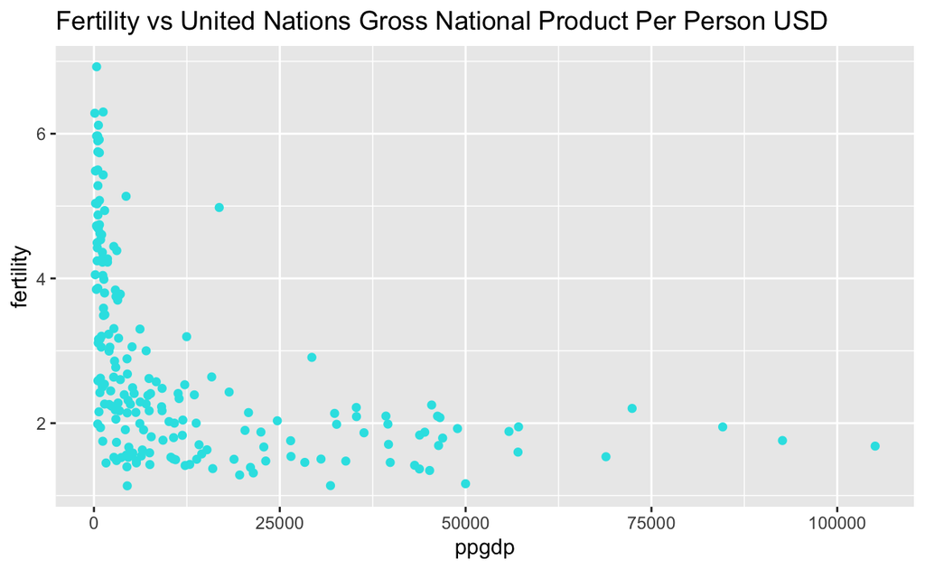

```r
United_Nations_11<-UN11
ggplot(data = UN11, aes(x = ppgdp ,y = fertility))+
  geom_point(color=5)+
  labs(title = "Fertility vs United Nations Gross National Product Per Person USD")
```

#### Analysis

This linear regression scatter plot does not appear to be an effective summary of the data. The mean is not linear and the variance is not constant. This could be partly attributed to the crowding of the x-axis and y-axis. Therefore, using natural logarithms for the x-axis and y-axis would be warranted to determine if there is any indication of the plausibility of a straight-line mean function.

**1.1.3 Draw the scatterplot of log(fertility) versus log(ppgdp) using natural logarithms. Does the simple linear regression model seem plausible for a summary of this graph? If you use a different base of logarithms, the shape of the graph won’t change, but the values on the axes will change.**

Scatterplot reflecting Natural Log of variables fertility vs. ppgdp

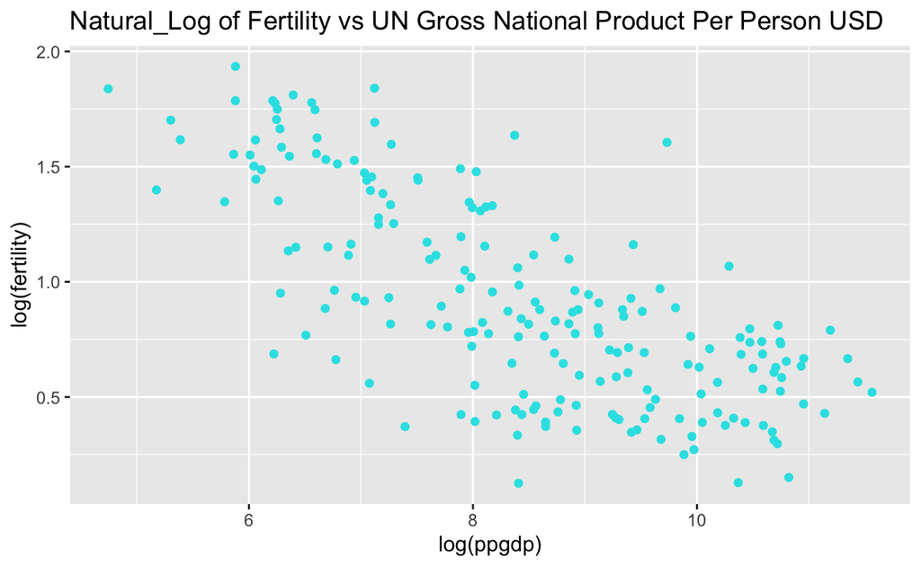

```r
United_Nations_11<-UN11
ggplot(data = UN11,aes(x = log(ppgdp),y = log(fertility)))+
  geom_point(color=5)+
  labs(title = "Natural_Log of Fertility vs UN Gross National Product Per Person USD")
```

Scatterplot reflecting Natural Log of variables fertility vs. ppgdp with linear regression

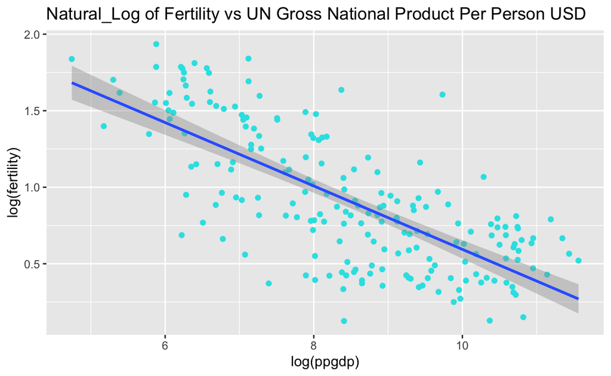

```r
United_Nations_11<-UN11
ggplot(data = UN11,aes(x = log(ppgdp),y = log(fertility)))+
  geom_point(color=5)+
  geom_smooth(method ="lm")+
  labs(title = "Natural_Log of Fertility vs UN Gross National Product Per Person USD")
```

#### Analysis

Implementation of the natural logarithmic scale for the UN11 scatterplot appears to indicate an effective representation of a linear regression. Compared to the previous scattorplot, this plot appears to be linear, and the variance seems to be plausible. Therefore, the relationship between fertility and gross domestic product(ppgdp )is linear.

## Question 2

Annual income, in dollars, is an explanatory variable in a regression analysis. For a British version of the report on the analysis, all responses are converted to British pounds sterling (1 pound equals about 1.33 dollars, as of 2016).

### Solution

**Part A**

#### How, if at all, does the slope of the prediction equation change?

When responses are converted to British pounds sterling the slope changes,thus the slope increases by **1.33 times** the original. This is because there is an inverse relationship between the slope,and the explanatory variables.

**Part B**

#### How, if at all, does the correlation change?

There will be no change in the correlation. This is because the strength and pattern (correlation) cannot be affected by change in units.

## Question 3

Water runoff in the Sierras (Data file: water) Can Southern California’s water supply in future years be predicted from past data? One factor affecting water availability is stream runoff. If runoff could be predicted, engineers, planners, and policy makers could do their jobs more efficiently. The data file contains 43 years’ worth of precipitation measurements taken at six sites in the Sierra Nevada mountains (labeled APMAM, APSAB, APSLAKE, OPBPC, OPRC, and OPSLAKE) and stream runoff volume at a site near Bishop, California, labeled BSAAM.

Draw the scatterplot matrix for these data and summarize the information available from these plots.

### Solution

First, we load the (Data files: water) and check the structure of the data

```r
data("water")                       #importing water data set
head(water,5)                       #looking at first 5 rows of data set
```

```
  Year APMAM APSAB APSLAKE OPBPC  OPRC OPSLAKE  BSAAM
1 1948  9.13  3.58    3.91  4.10  7.43    6.47  54235
2 1949  5.28  4.82    5.20  7.55 11.11   10.26  67567
3 1950  4.20  3.77    3.67  9.52 12.20   11.35  66161
4 1951  4.60  4.46    3.93 11.14 15.15   11.13  68094
5 1952  7.15  4.99    4.88 16.34 20.05   22.81 107080
```

```r
str(water)                          #concise look at data frame
```

```
'data.frame':   43 obs. of  8 variables:
 $ Year   : int  1948 1949 1950 1951 1952 1953 1954 1955 1956 1957 ...
 $ APMAM  : num  9.13 5.28 4.2 4.6 7.15 9.7 5.02 6.7 10.5 9.1 ...
 $ APSAB  : num  3.58 4.82 3.77 4.46 4.99 5.65 1.45 7.44 5.85 6.13 ...
 $ APSLAKE: num  3.91 5.2 3.67 3.93 4.88 4.91 1.77 6.51 3.38 4.08 ...
 $ OPBPC  : num  4.1 7.55 9.52 11.14 16.34 ...
 $ OPRC   : num  7.43 11.11 12.2 15.15 20.05 ...
 $ OPSLAKE: num  6.47 10.26 11.35 11.13 22.81 ...
 $ BSAAM  : int  54235 67567 66161 68094 107080 67594 65356 67909 92715 70024 ...
```

```r
summary(water)                      #provides numerical overview of data
```

```
      Year          APMAM            APSAB           APSLAKE
 Min.   :1948   Min.   : 2.700   Min.   : 1.450   Min.   : 1.77
 1st Qu.:1958   1st Qu.: 4.975   1st Qu.: 3.390   1st Qu.: 3.36
 Median :1969   Median : 7.080   Median : 4.460   Median : 4.62
 Mean   :1969   Mean   : 7.323   Mean   : 4.652   Mean   : 4.93
 3rd Qu.:1980   3rd Qu.: 9.115   3rd Qu.: 5.685   3rd Qu.: 5.83
 Max.   :1990   Max.   :18.080   Max.   :11.960   Max.   :13.02
     OPBPC             OPRC           OPSLAKE           BSAAM
 Min.   : 4.050   Min.   : 4.350   Min.   : 4.600   Min.   : 41785
 1st Qu.: 7.975   1st Qu.: 7.875   1st Qu.: 8.705   1st Qu.: 59857
 Median : 9.550   Median :11.110   Median :12.140   Median : 69177
 Mean   :12.836   Mean   :12.002   Mean   :13.522   Mean   : 77756
 3rd Qu.:16.545   3rd Qu.:14.975   3rd Qu.:16.920   3rd Qu.: 92206
 Max.   :43.370   Max.   :24.850   Max.   :33.070   Max.   :146345
```

For better readability and understandability of the data, a table is created

```r
library(DT)
datatable(head(water,25), options = list(
  columnDefs = list(list(className = 'dt-center',targets = 7)),
  rownames = T,
  pageLength = 5,
  autowidth = T,
  lengthMenu =c(5,10,15,20)
))
```

|  | Year | APMAM | APSAB | APSLAKE | OPBPC | OPRC | OPSLAKE | BSAAM |
| --- | --- | --- | --- | --- | --- | --- | --- | --- |
| 1 | 1948 | 9.13 | 3.58 | 3.91 | 4.1 | 7.43 | 6.47 | 54235 |
| 2 | 1949 | 5.28 | 4.82 | 5.2 | 7.55 | 11.11 | 10.26 | 67567 |
| 3 | 1950 | 4.2 | 3.77 | 3.67 | 9.52 | 12.2 | 11.35 | 66161 |
| 4 | 1951 | 4.6 | 4.46 | 3.93 | 11.14 | 15.15 | 11.13 | 68094 |
| 5 | 1952 | 7.15 | 4.99 | 4.88 | 16.34 | 20.05 | 22.81 | 107080 |
| 6 | 1953 | 9.7 | 5.65 | 4.91 | 8.88 | 8.15 | 7.41 | 67594 |
| 7 | 1954 | 5.02 | 1.45 | 1.77 | 13.57 | 12.45 | 13.32 | 65356 |
| 8 | 1955 | 6.7 | 7.44 | 6.51 | 9.28 | 9.65 | 9.8 | 67909 |
| 9 | 1956 | 10.5 | 5.85 | 3.38 | 21.2 | 18.55 | 17.42 | 92715 |
| 10 | 1957 | 9.1 | 6.13 | 4.08 | 9.55 | 9.2 | 8.25 | 70024 |

[output cut: 15 more lines]

Removing any missing data

```r
is.na(water) %>%     #removes missing values from variables we are working with
  summary()          #summary of data set, provides numerical insight
```

```
    Year           APMAM           APSAB          APSLAKE
 Mode :logical   Mode :logical   Mode :logical   Mode :logical
 FALSE:43        FALSE:43        FALSE:43        FALSE:43
   OPBPC            OPRC          OPSLAKE          BSAAM
 Mode :logical   Mode :logical   Mode :logical   Mode :logical
 FALSE:43        FALSE:43        FALSE:43        FALSE:43
```

**Draw the scatterplot matrix for these data and summarize the information available from these plots.**

We now draw a scatterplot matrix for the **water** data for better understandably

```r
#Since data has already been imported we can rename the water variable
water_supply<-water
head(water_supply,5)            #first five rows of dataset
```

```
  Year APMAM APSAB APSLAKE OPBPC  OPRC OPSLAKE  BSAAM
1 1948  9.13  3.58    3.91  4.10  7.43    6.47  54235
2 1949  5.28  4.82    5.20  7.55 11.11   10.26  67567
3 1950  4.20  3.77    3.67  9.52 12.20   11.35  66161
4 1951  4.60  4.46    3.93 11.14 15.15   11.13  68094
5 1952  7.15  4.99    4.88 16.34 20.05   22.81 107080
```

Scatterplot matrix for **water** data

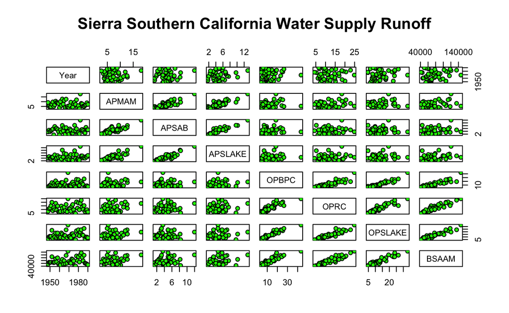

```r
pairs(water_supply,main = "Sierra Southern California Water Supply Runoff",
      pch = 21, bg = "green")
```

For more granular insight, we run a simple linear regression on the **water** data set

```r
#Simple linear regression of water data set

lm_water_supply<-lm(BSAAM~APMAM+APSAB+APSLAKE+OPBPC+OPRC+OPSLAKE,data = water)
summary(lm_water_supply)
```

```
Call:
lm(formula = BSAAM ~ APMAM + APSAB + APSLAKE + OPBPC + OPRC +
    OPSLAKE, data = water)

Residuals:
   Min     1Q Median     3Q    Max
-12690  -4936  -1424   4173  18542

Coefficients:
            Estimate Std. Error t value Pr(>|t|)
(Intercept) 15944.67    4099.80   3.889 0.000416 ***
APMAM         -12.77     708.89  -0.018 0.985725
APSAB        -664.41    1522.89  -0.436 0.665237
APSLAKE      2270.68    1341.29   1.693 0.099112 .
OPBPC          69.70     461.69   0.151 0.880839
OPRC         1916.45     641.36   2.988 0.005031 **
OPSLAKE      2211.58     752.69   2.938 0.005729 **
---
Signif. codes:  0 '***' 0.001 '**' 0.01 '*' 0.05 '.' 0.1 ' ' 1

Residual standard error: 7557 on 36 degrees of freedom
Multiple R-squared:  0.9248,    Adjusted R-squared:  0.9123
F-statistic: 73.82 on 6 and 36 DF,  p-value: < 2.2e-16
```

Analysis:

Starting with variable **Year** we see that it does not seem to be appear to be particularly related to any of the other variables.**APSLAKE,APSAB and APMAM** appear to be correlated, and it is observed in relation to the runoff variable **BSAAM** they do not seem to appear to have a strong correlation.

It appears that **OPSLAKE and OPRC** are strongly correlated as well being positively linear. This suggests statistical significance of the p-value in the linear regression **Pr(>|t|)< 0.05**.The **BSAAM** variable appears to be strongly correlated with them as well.Since these variables appear to be correlated with each other, it may cause a multicollinearity problem. Furthermore, with a p-value: < 2.2e-16 the model appears to be statistically significant. The residuals display of the regression a wide disparity from a *Minimum* of **-12690** to a *Maximum* of **18542**. This may suggest outliers in the model.

Finally, the **multiple R-squared: value of 0.9248** and the **Adjusted R-squared: 0.9123** values are close to 1 which suggests there is minimal overfitting.

## Question 4

Professor ratings (Data file: Rateprof) In the website and online forum RateMyProfessors.com, students rate and comment on their instructors. Launched in 1999, the site includes millions of ratings on thousands of instructors. The data file includes the summaries of the ratings of 364 instructors at a large campus in the Midwest (Bleske-Rechek and Fritsch, 2011). Each instructor included in the data had at least 10 ratings over a several year period. Students provided ratings of 1–5 on **quality, helpfulness, clarity, easiness of instructor’s courses, and raterInterest** in the subject matter covered in the instructor’s courses. The data file provides the averages of these five ratings. Use R to reproduce the scatterplot matrix in Figure 1.13 in the ALR book (page 20). Provide a brief description of the relationships between the five ratings. (The variables don’t have to be in the same order)

### Solution

First, the data (Data file: Rateprof) is imported from the ALR4 dataset

```r
data("Rateprof")
head(Rateprof,5)                           #first 5 rows of data
```

```
  gender numYears numRaters numCourses pepper discipline
1   male        7        11          5     no        Hum
2   male        6        11          5     no        Hum
3   male       10        43          2     no        Hum
4   male       11        24          5     no        Hum
5   male       11        19          7     no        Hum
               dept  quality helpfulness  clarity easiness
1           English 4.636364    4.636364 4.636364 4.818182
2 Religious Studies 4.318182    4.545455 4.090909 4.363636
3               Art 4.790698    4.720930 4.860465 4.604651
4           English 4.250000    4.458333 4.041667 2.791667
5           Spanish 4.684211    4.684211 4.684211 4.473684
  raterInterest sdQuality sdHelpfulness sdClarity sdEasiness
1      3.545455 0.5518564     0.6741999 0.5045250  0.4045199
2      4.000000 0.9020179     0.9341987 0.9438798  0.5045250
3      3.432432 0.4529343     0.6663898 0.4129681  0.5407021
4      3.181818 0.9325048     0.9315329 0.9990938  0.5882300
5      4.214286 0.6500112     0.8200699 0.5823927  0.6117753
  sdRaterInterest
1       1.1281521
2       1.0744356
3       1.2369438
4       1.3322506
5       0.9749613
```

Missing values are removed and then a summary of the data is run,to gain insight into the structure of the data.

```r
is.na(Rateprof) %>%        #removes missing values from variables we
summary()                  #insight into numerical data
```

```
   gender         numYears       numRaters       numCourses
 Mode :logical   Mode :logical   Mode :logical   Mode :logical
 FALSE:366       FALSE:366       FALSE:366       FALSE:366
   pepper        discipline         dept          quality
 Mode :logical   Mode :logical   Mode :logical   Mode :logical
 FALSE:366       FALSE:366       FALSE:366       FALSE:366
 helpfulness      clarity         easiness       raterInterest
 Mode :logical   Mode :logical   Mode :logical   Mode :logical
 FALSE:366       FALSE:366       FALSE:366       FALSE:366
 sdQuality       sdHelpfulness   sdClarity       sdEasiness
 Mode :logical   Mode :logical   Mode :logical   Mode :logical
 FALSE:366       FALSE:366       FALSE:366       FALSE:366
 sdRaterInterest
 Mode :logical
 FALSE:366
```

```r
str(Rateprof)
```

```
'data.frame':   366 obs. of  17 variables:
 $ gender         : Factor w/ 2 levels "female","male": 2 2 2 2 2 2 2 2 2 2 ...
 $ numYears       : int  7 6 10 11 11 10 7 11 11 7 ...
 $ numRaters      : int  11 11 43 24 19 15 17 16 12 18 ...
 $ numCourses     : int  5 5 2 5 7 9 3 3 4 4 ...
 $ pepper         : Factor w/ 2 levels "no","yes": 1 1 1 1 1 1 1 1 1 1 ...
 $ discipline     : Factor w/ 4 levels "Hum","SocSci",..: 1 1 1 1 1 1 1 1 1 1 ...
 $ dept           : Factor w/ 48 levels "Accounting","Anthropology",..: 17 42 3 17 45 45 45 17 34 17 ...
 $ quality        : num  4.64 4.32 4.79 4.25 4.68 ...
 $ helpfulness    : num  4.64 4.55 4.72 4.46 4.68 ...
 $ clarity        : num  4.64 4.09 4.86 4.04 4.68 ...
 $ easiness       : num  4.82 4.36 4.6 2.79 4.47 ...
 $ raterInterest  : num  3.55 4 3.43 3.18 4.21 ...
 $ sdQuality      : num  0.552 0.902 0.453 0.933 0.65 ...
 $ sdHelpfulness  : num  0.674 0.934 0.666 0.932 0.82 ...
 $ sdClarity      : num  0.505 0.944 0.413 0.999 0.582 ...
 $ sdEasiness     : num  0.405 0.505 0.541 0.588 0.612 ...
 $ sdRaterInterest: num  1.128 1.074 1.237 1.332 0.975 ...
```

Five variables we are focused on extracted from **Rateprof** dataset.

```r
#data set renamed for subset
rate_my_prof<-Rateprof
colnames(rate_my_prof)            #column names in dataset
```

```
 [1] "gender"          "numYears"        "numRaters"
 [4] "numCourses"      "pepper"          "discipline"
 [7] "dept"            "quality"         "helpfulness"
[10] "clarity"         "easiness"        "raterInterest"
[13] "sdQuality"       "sdHelpfulness"   "sdClarity"
[16] "sdEasiness"      "sdRaterInterest"
```

Five variable subset of **RateProf** dataset

```r
#subset of RateProf data

rate_my_prof<-select(Rateprof,c('quality','helpfulness','clarity','easiness','raterInterest'))
head(rate_my_prof)     #first 5 rows of data set
```

```
   quality helpfulness  clarity easiness raterInterest
1 4.636364    4.636364 4.636364 4.818182      3.545455
2 4.318182    4.545455 4.090909 4.363636      4.000000
3 4.790698    4.720930 4.860465 4.604651      3.432432
4 4.250000    4.458333 4.041667 2.791667      3.181818
5 4.684211    4.684211 4.684211 4.473684      4.214286
6 4.233333    4.266667 4.200000 4.533333      3.916667
```

Table of subset of data for better understandability

```r
kable(head(rate_my_prof),format = "markdown",digits = 5,
colnames = c('Quality','Helpfulness','Clarity','Easiness','RaterInterest'),caption
= "Rate My Professor")
```

Table 2: Rate My Professor

| quality | helpfulness | clarity | easiness | raterInterest |
| --- | --- | --- | --- | --- |
| 4.63636 | 4.63636 | 4.63636 | 4.81818 | 3.54545 |
| 4.31818 | 4.54545 | 4.09091 | 4.36364 | 4.00000 |
| 4.79070 | 4.72093 | 4.86047 | 4.60465 | 3.43243 |
| 4.25000 | 4.45833 | 4.04167 | 2.79167 | 3.18182 |
| 4.68421 | 4.68421 | 4.68421 | 4.47368 | 4.21429 |
| 4.23333 | 4.26667 | 4.20000 | 4.53333 | 3.91667 |

Scatterplot Matrix of five RateProf variables

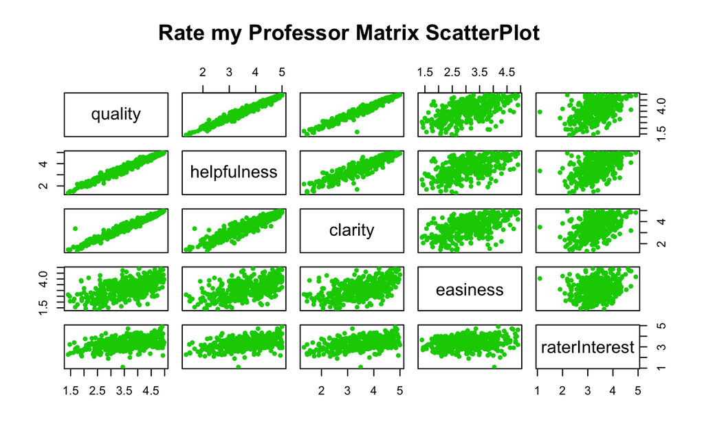

```r
pairs(rate_my_prof,
      col = "green3",
      pch = 20,
      main = "Rate my Professor Matrix ScatterPlot ")
```

**Provide a brief description of the relationships between the five ratings**

Interpretation:

We see that if there is an intersection of any two variables then there is linear correlation of varying degrees of strength. Furthermore,if the correlation is not as linear then the correlation is weak.

We see that the relationship between some pairs of variables indicate better positive linear correlations than others.

- **Quality-Clarity** indicates a very strong positive linear correlation
- **Quality-Happiness** indicates a very strong positive linear correlation
- **Quality-Easiness** indicates a weak positive linear correlation
- **Quality-RaterInterest** indicates a weak positive linear correlation
- **Helpfulness-Easiness** indicates a weak linear correlation
- **Helpfulness-RaterInterest** indicates a weak linear correlation
- **Clarity-Helpfulness** indicates a positive correlation
- **Clarity-RaterInterest** indicates a weak positive correlation
- **Clarity-Easiness** indicates a weak positive correlation
- **Easiness and RaterInterest** indicates a very weak positive correlation

## Question 5

(Problem 9.34 in SMSS)

For the student.survey data file in the smss package, conduct regression analyses relating (i) y = political ideology and x = religiosity, (ii) y = high school GPA and x = hours of TV watching.

(You can use **?student.survey** in the R console, after loading the package, to see what each variable means.)

- 1. Use graphical ways to portray the individual variables and their relationship.
- 2. Interpret descriptive statistics for summarizing the individual variables and their relationship.
- 3. Summarize and interpret results of inferential analyses.

### Solution

I first, import and inspect the **student.survey** dataset from SMSS text.

```r
data("student.survey")                   #import dataset
student_survey_data<-student.survey      #renamed for better understandability
head(student_survey_data,5)              #inspects first five rows of data
```

```
  subj ge ag  hi  co   dh   dr tv sp ne ah    ve pa           pi
1    1  m 32 2.2 3.5    0  5.0  3  5  0  0 FALSE  r conservative
2    2  f 23 2.1 3.5 1200  0.3 15  7  5  6 FALSE  d      liberal
3    3  f 27 3.3 3.0 1300  1.5  0  4  3  0 FALSE  d      liberal
4    4  f 35 3.5 3.2 1500  8.0  5  5  6  3 FALSE  i     moderate
5    5  m 23 3.1 3.5 1600 10.0  6  6  3  0 FALSE  i very liberal
            re    ab    aa    ld
1   most weeks FALSE FALSE FALSE
2 occasionally FALSE FALSE    NA
3   most weeks FALSE FALSE    NA
4 occasionally FALSE FALSE FALSE
5        never FALSE FALSE FALSE
```

To gain better understanding of the data I look at a summery, strings,and column names of the data set

```r
colnames(student_survey_data)                 #column names of dataset
```

```
 [1] "subj" "ge"   "ag"   "hi"   "co"   "dh"   "dr"   "tv"   "sp"
[10] "ne"   "ah"   "ve"   "pa"   "pi"   "re"   "ab"   "aa"   "ld"
```

```r
summary(student_survey_data)                  #numeric structure of data
```

```
      subj       ge           ag              hi
 Min.   : 1.00   f:31   Min.   :22.00   Min.   :2.000
 1st Qu.:15.75   m:29   1st Qu.:24.00   1st Qu.:3.000
 Median :30.50          Median :26.50   Median :3.350
 Mean   :30.50          Mean   :29.17   Mean   :3.308
 3rd Qu.:45.25          3rd Qu.:31.00   3rd Qu.:3.625
 Max.   :60.00          Max.   :71.00   Max.   :4.000

       co              dh             dr               tv
 Min.   :2.600   Min.   :   0   Min.   : 0.200   Min.   : 0.000
 1st Qu.:3.175   1st Qu.: 205   1st Qu.: 1.450   1st Qu.: 3.000
 Median :3.500   Median : 640   Median : 2.000   Median : 6.000
 Mean   :3.453   Mean   :1232   Mean   : 3.818   Mean   : 7.267
 3rd Qu.:3.725   3rd Qu.:1350   3rd Qu.: 5.000   3rd Qu.:10.000
 Max.   :4.000   Max.   :8000   Max.   :20.000   Max.   :37.000

       sp               ne               ah             ve
 Min.   : 0.000   Min.   : 0.000   Min.   : 0.000   Mode :logical
 1st Qu.: 3.000   1st Qu.: 2.000   1st Qu.: 0.000   FALSE:60
 Median : 5.000   Median : 3.000   Median : 0.500
 Mean   : 5.483   Mean   : 4.083   Mean   : 1.433
 3rd Qu.: 7.000   3rd Qu.: 5.250   3rd Qu.: 2.000
 Max.   :16.000   Max.   :14.000   Max.   :11.000

 pa                         pi                re         ab
 d:21   very liberal         : 8   never       :15   Mode :logical
 i:24   liberal              :24   occasionally:29   FALSE:60
 r:15   slightly liberal     : 6   most weeks  : 7
        moderate             :10   every week  : 9
        slightly conservative: 6
        conservative         : 4
        very conservative    : 2
     aa              ld
 Mode :logical   Mode :logical
 FALSE:59        FALSE:44
 NA's :1         NA's :16
```

```r
str(student_survey_data)
```

```
'data.frame':   60 obs. of  18 variables:
 $ subj: int  1 2 3 4 5 6 7 8 9 10 ...
 $ ge  : Factor w/ 2 levels "f","m": 2 1 1 1 2 2 2 1 2 2 ...
 $ ag  : int  32 23 27 35 23 39 24 31 34 28 ...
 $ hi  : num  2.2 2.1 3.3 3.5 3.1 3.5 3.6 3 3 4 ...
 $ co  : num  3.5 3.5 3 3.2 3.5 3.5 3.7 3 3 3.1 ...
 $ dh  : int  0 1200 1300 1500 1600 350 0 5000 5000 900 ...
 $ dr  : num  5 0.3 1.5 8 10 3 0.2 1.5 2 2 ...
 $ tv  : num  3 15 0 5 6 4 5 5 7 1 ...
 $ sp  : int  5 7 4 5 6 5 12 3 5 1 ...
 $ ne  : int  0 5 3 6 3 7 4 3 3 2 ...
 $ ah  : int  0 6 0 3 0 0 2 1 0 1 ...
 $ ve  : logi  FALSE FALSE FALSE FALSE FALSE FALSE ...
 $ pa  : Factor w/ 3 levels "d","i","r": 3 1 1 2 2 1 2 2 2 2 ...
 $ pi  : Ord.factor w/ 7 levels "very liberal"<..: 6 2 2 4 1 2 2 2 1 3 ...
 $ re  : Ord.factor w/ 4 levels "never"<"occasionally"<..: 3 2 3 2 1 2 2 2 2 1 ...
 $ ab  : logi  FALSE FALSE FALSE FALSE FALSE FALSE ...
 $ aa  : logi  FALSE FALSE FALSE FALSE FALSE FALSE ...
 $ ld  : logi  FALSE NA NA FALSE FALSE NA ...
```

Subset of data extracted from student survey dataset we are inspecting

```r
student_survey_data<-student_survey_data %>%
  select(c(pi,re,hi,tv))               #data subset for plots
  head(student_survey_data,5)
```

```
            pi           re  hi tv
1 conservative   most weeks 2.2  3
2      liberal occasionally 2.1 15
3      liberal   most weeks 3.3  0
4     moderate occasionally 3.5  5
5 very liberal        never 3.1  6
```

Missing values are removed and then a summary of the data is run to gain insight and inspect structure of the data.

```r
is.na(student_survey_data) %>%         #removes missing values from data
summary(student_survey_data)
```

```
     pi              re              hi              tv
 Mode :logical   Mode :logical   Mode :logical   Mode :logical
 FALSE:60        FALSE:60        FALSE:60        FALSE:60
```

For easier readability the data is placed in a table.

```r
kable(head(student_survey_data),format = "markdown",digits = 3,
col.names = c('Political_Ideology','Religiosity','HighSchoolGPA','HoursTVWatched'),caption
= "Student_Survey_Data")
```

Table 3: Student_Survey_Data

| Political_Ideology | Religiosity | HighSchoolGPA | HoursTVWatched |
| --- | --- | --- | --- |
| conservative | most weeks | 2.2 | 3 |
| liberal | occasionally | 2.1 | 15 |
| liberal | most weeks | 3.3 | 0 |
| moderate | occasionally | 3.5 | 5 |
| very liberal | never | 3.1 | 6 |
| liberal | occasionally | 3.5 | 4 |

Part A

**Use graphical ways to portray the individual variables and their relationship.**

**i)** Now that we know the structure of the data we can represent it visually with a plot. The first plot represents variables: y = political ideology(pi) vs x = religiosity(re).

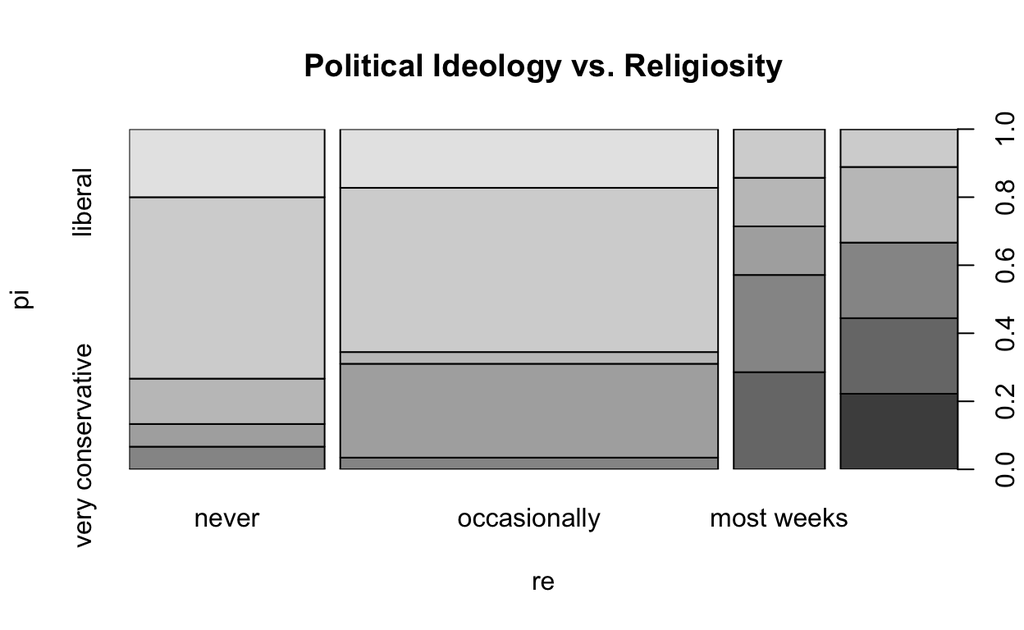

```r
student_survey_plot<-plot(pi~re,data = student.survey,
        #survey plot using plot function
                          main = "Political Ideology vs. Religiosity")
```

I use xtabs() function to gain further insight into the data since it is categorical.

```r
data("student.survey")
xtabs(~pi+re,student.survey)
```

```
                       re
pi                      never occasionally most weeks every week
  very liberal              3            5          0          0
  liberal                   8           14          1          1
  slightly liberal          2            1          1          2
  moderate                  1            8          1          0
  slightly conservative     1            1          2          2
  conservative              0            0          2          2
  very conservative         0            0          0          2
```

**ii)**

The second plot is represented visually with the following variables: y = high school GPA(hi) and x = hours of TV watching(tv). Since the variables are numeric it is more straight forward for interpretation.

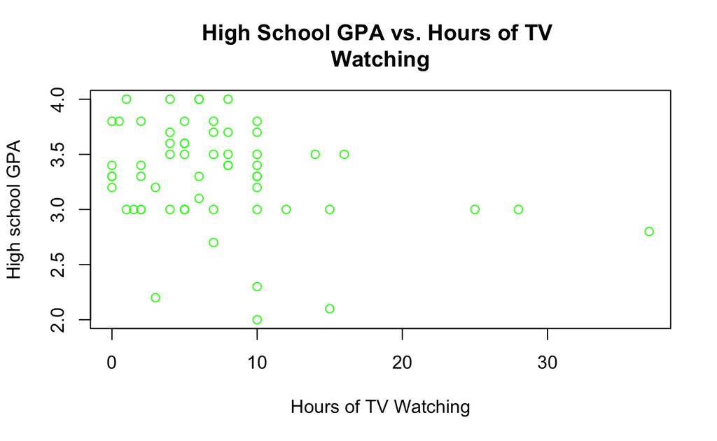

```r
student_survey_plot<-plot(hi~tv,data = student.survey,
                          xlab="Hours of TV Watching",
                          ylab="High school GPA",
                          col = "green",
                          main = "High School GPA vs. Hours of TV
Watching")                #survey plot using plot function
```

Analysis:

Inspection of the Political Ideology(pi) vs. Religiosity(re) plot yielded very little meaningful information in its current form, as a categorical subset of the data. I used the **xtabs() function** to gain further insight in to the data since it is categorical. Whereas, the Hours of TV Watching(tv) and High school GPA(hi) data are numeric and did yield some insight. I will further explore any correlations in Part B.

Part B

**Interpret descriptive statistics for summarizing the individual variables and their relationship.**

**i)**

I rename all 4 variables of the subset for better understandability

```r
student_survey_rename<-student.survey %>%
  rename(Political_Ideology=pi) %>%
  rename(Religiosity=re) %>%
  rename(Hours_of_TV=tv) %>%
  rename(HighSchool_GPA=hi)
```

I then use my favorite tool, the table to gain further insight into the **political ideology** and **religiosity** variables.

```r
data("student.survey")
xtabs(~Political_Ideology+Religiosity,student_survey_rename)
```

```
                       Religiosity
Political_Ideology      never occasionally most weeks every week
  very liberal              3            5          0          0
  liberal                   8           14          1          1
  slightly liberal          2            1          1          2
  moderate                  1            8          1          0
  slightly conservative     1            1          2          2
  conservative              0            0          2          2
  very conservative         0            0          0          2
```

Summary of 4 variables **pi,re,hi,tv**

```r
summary(student_survey_data)
```

```
                     pi                re           hi
 very liberal         : 8   never       :15   Min.   :2.000
 liberal              :24   occasionally:29   1st Qu.:3.000
 slightly liberal     : 6   most weeks  : 7   Median :3.350
 moderate             :10   every week  : 9   Mean   :3.308
 slightly conservative: 6                     3rd Qu.:3.625
 conservative         : 4                     Max.   :4.000
 very conservative    : 2
       tv
 Min.   : 0.000
 1st Qu.: 3.000
 Median : 6.000
 Mean   : 7.267
 3rd Qu.:10.000
 Max.   :37.000
```

**ii)**

Here I use a linear model to determine if there is a correlation between **Highschool GPA and Hours Watching TV**

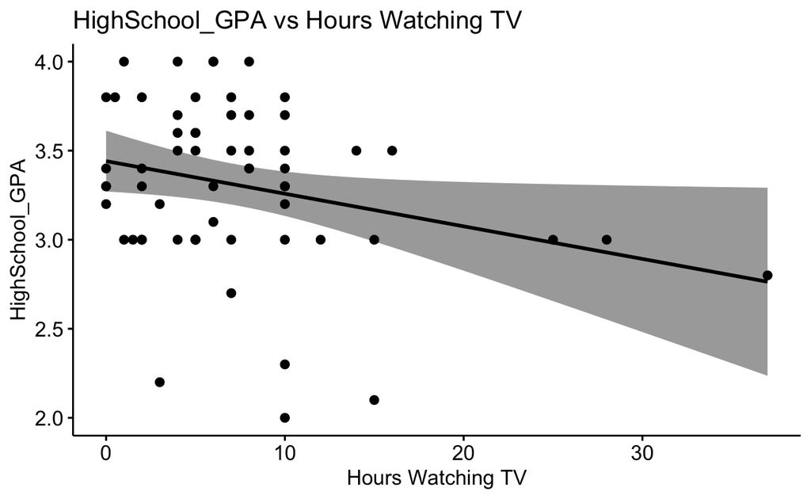

```r
ggscatter(student.survey,x="tv",y="hi",
          add = "reg.line",conf.int = TRUE,
          xlab = "Hours Watching TV",ylab = "HighSchool_GPA",title = "HighSchool_GPA vs Hours Watching TV")
```

I can now gain further insight into the variables high school gpa(hi) and hours watching tv(tv)

```r
skim(student_survey_data)      #provides concise,descriptive insight into the data
```

Table 4: Data summary

| Name | student_survey_data |
| --- | --- |
| Number of rows | 60 |
| Number of columns | 4 |
| _______________________ |  |
| Column type frequency: |  |
| factor | 2 |
| numeric | 2 |
| ________________________ |  |
| Group variables | None |

**Variable type: factor**

| skim_variable | n_missing | complete_rate | ordered | n_unique | top_counts |
| --- | --- | --- | --- | --- | --- |
| pi | 0 | 1 | TRUE | 7 | lib: 24, mod: 10, ver: 8, sli: 6 |
| re | 0 | 1 | TRUE | 4 | occ: 29, nev: 15, eve: 9, mos: 7 |

**Variable type: numeric**

| skim_variable | n_missing | complete_rate | mean | sd | p0 | p25 | p50 | p75 | p100 | hist |
| --- | --- | --- | --- | --- | --- | --- | --- | --- | --- | --- |
| hi | 0 | 1 | 3.31 | 0.46 | 2 | 3 | 3.35 | 3.62 | 4 | ▂▁▇▇▆ |
| tv | 0 | 1 | 7.27 | 6.72 | 0 | 3 | 6.00 | 10.00 | 37 | ▇▃▁▁▁ |

```r
str(student_survey_data)
```

```
'data.frame':   60 obs. of  4 variables:
 $ pi: Ord.factor w/ 7 levels "very liberal"<..: 6 2 2 4 1 2 2 2 1 3 ...
 $ re: Ord.factor w/ 4 levels "never"<"occasionally"<..: 3 2 3 2 1 2 2 2 2 1 ...
 $ hi: num  2.2 2.1 3.3 3.5 3.1 3.5 3.6 3 3 4 ...
 $ tv: num  3 15 0 5 6 4 5 5 7 1 ...
```

```r
summary(student_survey_data)
```

```
                     pi                re           hi
 very liberal         : 8   never       :15   Min.   :2.000
 liberal              :24   occasionally:29   1st Qu.:3.000
 slightly liberal     : 6   most weeks  : 7   Median :3.350
 moderate             :10   every week  : 9   Mean   :3.308
 slightly conservative: 6                     3rd Qu.:3.625
 conservative         : 4                     Max.   :4.000
 very conservative    : 2
       tv
 Min.   : 0.000
 1st Qu.: 3.000
 Median : 6.000
 Mean   : 7.267
 3rd Qu.:10.000
 Max.   :37.000
```

Interpretation:

Students **Highschool GPA** has a mean of 3.31gpa and median of 3.35gpa. The GPA’s are within a range of 2.00 for minimum and 4.00 for maximum. It has a standard deviation of 0.46 which indicates the data are clustered around the mean. This is verified in the graph.

Students **Hours Watching TV** has a *mean of 7.3 hours*, *median of 6 hours*. The hours watched range from a minimum of **0** to a maximum value of 37 hours per week.

PART C

Summarize and interpret results of inferential analyses.

**i)**

To gain better insight into the **political ideology and religiosity variables**, I use the function cor.test() (as discussed in class).The cor.test() function will provide an association or correlation between paired samples **political ideology(pi) and religiosity variables(re)**.

```r
# correlation test
cor.test(as.numeric(student_survey_data$pi),as.numeric(student_survey_data$re))
```

```
    Pearson's product-moment correlation

data:  as.numeric(student_survey_data$pi) and as.numeric(student_survey_data$re)
t = 5.4163, df = 58, p-value = 1.221e-06
alternative hypothesis: true correlation is not equal to 0
95 percent confidence interval:
 0.3818345 0.7265650
sample estimates:
      cor
0.5795661
```

To gain better insight into the “HighSchoolGPA vs Hours Watching TV” I use a **cor.test** as discussed in class

```r
cor.test(as.numeric(student_survey_data$hi),as.numeric(student_survey_data$tv))
```

```
    Pearson's product-moment correlation

data:  as.numeric(student_survey_data$hi) and as.numeric(student_survey_data$tv)
t = -2.1144, df = 58, p-value = 0.03879
alternative hypothesis: true correlation is not equal to 0
95 percent confidence interval:
 -0.48826914 -0.01457694
sample estimates:
       cor
-0.2675115
```

**ii)**

Pearson correlation plot “HighSchoolGPA vs Hours Watching TV”

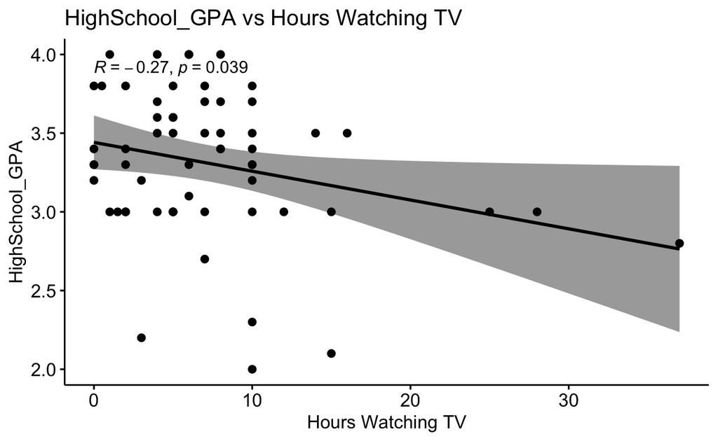

```r
ggscatter(student.survey,x="tv",y="hi",
          add = "reg.line",conf.int = TRUE,
          cor.coef=TRUE,cor.method = "pearson",
          xlab = "Hours Watching TV",ylab = "HighSchool_GPA",title = "HighSchool_GPA vs Hours Watching TV")
```

Interpretation:

Test statistic = -2.1144

Based on the **cor.test** we see the correlation between **gpa and television watching** is statistically significant since the **p-value is < 0.05** at p-value: 0.039, we therefore reject the null hypothesis. Graphically we also observe there is a moderately weak negative correlation between **gpa and television watching**.

## Question 6

For a class of 100 students, the teacher takes the 10 students who perform poorest on the midterm exam and enrolls them in a special tutoring program. The overall class mean is 70 on both the midterm and final, but the mean for the specially tutored students increases from 50 to 60. Use the concept of regression toward the mean to explain why this is not sufficient evidence to imply that the tutoring program was successful.

### Solution

Regression toward the mean is an idea that refers to the fact that if one sample of a random variable is extreme, the next sampling of the same random variable is likely to be closer to its mean.

In this case, the original sample mean of the specially tutored students was 50 which is very low compared to the overall class sample mean of 70; therefore the next sampling of the same set of the specially tutored students is likely to produce a value of a sample mean closer to the overall mean of 70; and this is purely due to the **statistical phenomenon of regression towards mean** and not due to any special effect of the special tutoring program ; even without the special tutoring program, this second sample mean would most likely be closer to 70 than the first sample mean.